# Complex_Diet Data Analysis

## Complex_Protein Report

This report is dived in two parts, first is all the metagenomics statistical analysis. Just to remeber, here we already have done all the bioinformatics part. Which are: Remove low quality reads, remove host contamination, put taxonomic with kraken2 and calculate the total or relative abundace of reads for each taxonomic unit. Now we will load all the files in R and the metadata.

## Load packages

```r
library(tidyverse)
library(BiocManager)
library(phyloseq)
library(labdsv)
library(ape)
library(Maaslin2)
library(ggplot2)
library(dplyr)
library(forcats)
library(viridis)
library(vegan)
library(knitr)
library(mixOmics)
library(ALDEx2)
library(ComplexHeatmap)
library(circlize)
library(RColorBrewer)
library(ANCOMBC)
library(Biostrings)
library(scater)
library(TreeSummarizedExperiment)
library(mia)
library(metagMisc)
library(devtools)
library(pairwiseAdonis)
library(ggpubr)
library(openxlsx)
library(maaslin3)
library(patchwork)
```

## Load data

```r
#| label: load-bracken-data

# Load all taxonomic levels
domain_raw <- read.delim("merged_D_abundance.txt", header = TRUE, row.names = 1, check.names = FALSE)
phylum_raw <- read.delim("merged_P_abundance.txt", header = TRUE, row.names = 1, check.names = FALSE)
class_raw <- read.delim("merged_C_abundance.txt", header = TRUE, row.names = 1, check.names = FALSE)
order_raw <- read.delim("merged_O_abundance.txt", header = TRUE, row.names = 1, check.names = FALSE)
family_raw <- read.delim("merged_F_abundance.txt", header = TRUE, row.names = 1, check.names = FALSE)
genus_raw <- read.delim("merged_G_abundance.txt", header = TRUE, row.names = 1, check.names = FALSE)
species_raw <- read.delim("merged_S_abundance.txt", header = TRUE, row.names = 1, check.names = FALSE)

# Load metadata
meta_tab <- read.csv("meta.csv", row.names = 1)
```

## Separate counts and fractions (using species as example - repeat for other levels)

```r
# Get column names
all_cols <- colnames(species_raw)

# Identify count columns (end with _num) and fraction columns (end with _frac)
num_cols <- grep("_num$", all_cols, value = TRUE)
frac_cols <- grep("_frac$", all_cols, value = TRUE)

# Create clean sample names (remove .bracken_num suffix)
sample_names <- gsub("\\.bracken_num$", "", num_cols)

# Extract counts matrix
species_counts <- species_raw[, num_cols]
colnames(species_counts) <- sample_names
species_counts <- as.matrix(species_counts)
storage.mode(species_counts) <- "numeric"

# Extract fractions matrix
species_frac <- species_raw[, frac_cols]
colnames(species_frac) <- sample_names
species_frac <- as.matrix(species_frac)
storage.mode(species_frac) <- "numeric"

# Check dimensions
dim(species_counts)
```

```
[1] 2671   29
```

```r
dim(species_frac)
```

```
[1] 2671   29
```

### Repeat for all taxonomic levels:

```r
#| label: process-all-levels

# Domain
num_cols <- grep("_num$", colnames(domain_raw), value = TRUE)
frac_cols <- grep("_frac$", colnames(domain_raw), value = TRUE)
sample_names <- gsub("\\.bracken_num$", "", num_cols)

domain_counts <- as.matrix(domain_raw[, num_cols])
colnames(domain_counts) <- sample_names
storage.mode(domain_counts) <- "numeric"

domain_frac <- as.matrix(domain_raw[, frac_cols])
colnames(domain_frac) <- sample_names
storage.mode(domain_frac) <- "numeric"

# Phylum
num_cols <- grep("_num$", colnames(phylum_raw), value = TRUE)
frac_cols <- grep("_frac$", colnames(phylum_raw), value = TRUE)
sample_names <- gsub("\\.bracken_num$", "", num_cols)

phylum_counts <- as.matrix(phylum_raw[, num_cols])
colnames(phylum_counts) <- sample_names
storage.mode(phylum_counts) <- "numeric"

phylum_frac <- as.matrix(phylum_raw[, frac_cols])
colnames(phylum_frac) <- sample_names
storage.mode(phylum_frac) <- "numeric"

# Class
num_cols <- grep("_num$", colnames(class_raw), value = TRUE)
frac_cols <- grep("_frac$", colnames(class_raw), value = TRUE)
sample_names <- gsub("\\.bracken_num$", "", num_cols)

class_counts <- as.matrix(class_raw[, num_cols])
colnames(class_counts) <- sample_names
storage.mode(class_counts) <- "numeric"

class_frac <- as.matrix(class_raw[, frac_cols])
colnames(class_frac) <- sample_names
storage.mode(class_frac) <- "numeric"

# Order
num_cols <- grep("_num$", colnames(order_raw), value = TRUE)
frac_cols <- grep("_frac$", colnames(order_raw), value = TRUE)
sample_names <- gsub("\\.bracken_num$", "", num_cols)

order_counts <- as.matrix(order_raw[, num_cols])
colnames(order_counts) <- sample_names
storage.mode(order_counts) <- "numeric"

order_frac <- as.matrix(order_raw[, frac_cols])
colnames(order_frac) <- sample_names
storage.mode(order_frac) <- "numeric"

# Family
num_cols <- grep("_num$", colnames(family_raw), value = TRUE)
frac_cols <- grep("_frac$", colnames(family_raw), value = TRUE)
sample_names <- gsub("\\.bracken_num$", "", num_cols)

family_counts <- as.matrix(family_raw[, num_cols])
colnames(family_counts) <- sample_names
storage.mode(family_counts) <- "numeric"

family_frac <- as.matrix(family_raw[, frac_cols])
colnames(family_frac) <- sample_names
storage.mode(family_frac) <- "numeric"

# Genus
num_cols <- grep("_num$", colnames(genus_raw), value = TRUE)
frac_cols <- grep("_frac$", colnames(genus_raw), value = TRUE)
sample_names <- gsub("\\.bracken_num$", "", num_cols)

genus_counts <- as.matrix(genus_raw[, num_cols])
colnames(genus_counts) <- sample_names
storage.mode(genus_counts) <- "numeric"

genus_frac <- as.matrix(genus_raw[, frac_cols])
colnames(genus_frac) <- sample_names
storage.mode(genus_frac) <- "numeric"
```

### Align samples between data and metadata:

```r
# Find common samples between data and metadata
common_samples <- intersect(colnames(species_counts), rownames(meta_tab))
length(common_samples)
```

```
[1] 29
```

```r
# Subset and reorder all matrices and metadata
meta_tab <- meta_tab[common_samples, ]

domain_counts <- domain_counts[, common_samples]
domain_frac <- domain_frac[, common_samples]

phylum_counts <- phylum_counts[, common_samples]
phylum_frac <- phylum_frac[, common_samples]

class_counts <- class_counts[, common_samples]
class_frac <- class_frac[, common_samples]

order_counts <- order_counts[, common_samples]
order_frac <- order_frac[, common_samples]

family_counts <- family_counts[, common_samples]
family_frac <- family_frac[, common_samples]

genus_counts <- genus_counts[, common_samples]
genus_frac <- genus_frac[, common_samples]

species_counts <- species_counts[, common_samples]
species_frac <- species_frac[, common_samples]
```

## **Set up factors and colorblind-friendly palette:**

```r
# Convert metadata columns to factors
meta_tab$complex <- factor(meta_tab$complex, levels = c("low", "medium", "high"))
meta_tab$protease <- factor(meta_tab$protease, levels = c("cont", "prot"))
meta_tab$interaction <- factor(meta_tab$interaction)

# Colorblind-friendly palette (Wong, 2011 - Nature Methods)
cb_palette <- c("#E69F00", "#56B4E9", "#009E73", "#F0E442",
                "#0072B2", "#D55E00", "#CC79A7", "#999999")

# Assign consistent colors to your treatment groups
complex_colors <- c("low" = "#56B4E9", "medium" = "#E69F00", "high" = "#009E73")
protease_colors <- c("cont" = "#0072B2", "prot" = "#D55E00")

# Publication-ready theme for ggplot
theme_publication <- theme_bw(base_size = 12) +
  theme(
    panel.grid.major = element_blank(),
    panel.grid.minor = element_blank(),
    panel.border = element_rect(color = "black", linewidth = 1),
    axis.text = element_text(color = "black"),
    axis.title = element_text(face = "bold"),
    legend.background = element_rect(color = "black", linewidth = 0.5),
    legend.title = element_text(face = "bold"),
    strip.background = element_rect(fill = "grey90", color = "black"),
    strip.text = element_text(face = "bold"),
    plot.title = element_text(hjust = 0.5, face = "bold")
  )
```

#### Quick data summary:

```r
# Summary of taxa per level
data.frame(
  Level = c("Domain", "Phylum", "Class", "Order", "Family", "Genus", "Species"),
  N_Taxa = c(nrow(domain_counts), nrow(phylum_counts), nrow(class_counts),
             nrow(order_counts), nrow(family_counts), nrow(genus_counts),
             nrow(species_counts)),
  N_Samples = ncol(species_counts)
)
```

```
    Level N_Taxa N_Samples
1  Domain      4        29
2  Phylum     44        29
3   Class     88        29
4   Order    192        29
5  Family    440        29
6   Genus   1267        29
7 Species   2671        29
```

## Alpha Diversity

### Calculate alpha diversity metrics:

Bruno, a diversidade alpha é feito sobre a relativa abundance. Se vc somar a relativa abudancia de todas as especies dentro uma amostra tem que dar um ou bem proximo de 1. Faz sentido? Diversidade alpha tem varias metricas, aqui eu coloquei as principais. Entretento, a metrica CHAO1, tem que ser feito sobre o numero de counts e nao abundancia relativa. Obseerva que as tabelas tem o nome diferente “_counts”.

```r
# Transpose matrix (vegan needs samples as rows)
species_frac_t <- t(species_frac)
species_count_t <- t(species_counts)


library(vegan)

# Calculate alpha diversity metrics
alpha_div <- data.frame(
  sample    = rownames(species_frac_t),
  observed  = specnumber(species_frac_t),
  shannon   = diversity(species_frac_t, index = "shannon"),
  simpson   = diversity(species_frac_t, index = "simpson"),
  invsimpson = diversity(species_frac_t, index = "invsimpson")
)


# Add Chao1 (needs integer counts)
chao1_values <- estimateR(round(species_count_t))
alpha_div$chao1 <- chao1_values["S.chao1", ]

# Add Pielou's evenness (J = H / ln(S))
alpha_div$pielou <- alpha_div$shannon / log(alpha_div$observed)

# Merge with metadata
alpha_div <- merge(alpha_div, meta_tab, by.x = "sample", by.y = "row.names")

head(alpha_div)
```

```
  sample observed  shannon   simpson invsimpson chao1    pielou code tag weight
1   2827      579 3.244500 0.8926665   9.316758   579 0.5100371    3 815  32.00
2   2828      459 2.360992 0.7056383   3.397181   459 0.3852133    4 867  32.60
3   2830      799 3.629339 0.8813789   8.430207   799 0.5430411    6 911  33.80
4   2831      732 3.274195 0.8290662   5.850216   732 0.4964075    7 762  33.45
5   2832     1107 3.645070 0.8277069   5.804064  1107 0.5200253    8 773  29.75
6   2833     1558 4.092507 0.9268360  13.667922  1558 0.5567159    9 791  30.90
  pen trt complex protease interaction
1  41   3     low     prot        BCCP
2  31   4    high     cont        ACSP
3  29   6     low     cont        BCSP
4  42   5  medium     cont        MCSP
5  14   3     low     prot        BCCP
6  13   5  medium     cont        MCSP
```

#### Statistical tests for Complex factor:

```r
# Kruskal-Wallis test for each metric (complex has 3 levels)
kruskal_observed_complex <- kruskal.test(observed ~ complex, data = alpha_div)
kruskal_shannon_complex <- kruskal.test(shannon ~ complex, data = alpha_div)
kruskal_simpson_complex <- kruskal.test(simpson ~ complex, data = alpha_div)
kruskal_invsimpson_complex <- kruskal.test(invsimpson ~ complex, data = alpha_div)
kruskal_chao1_complex <- kruskal.test(chao1 ~ complex, data = alpha_div)
kruskal_pielou_complex <- kruskal.test(pielou ~ complex, data = alpha_div)

# Summary table
stats_complex <- data.frame(
  Metric = c("Observed", "Shannon", "Simpson", "InvSimpson", "Chao1", "Pielou"),
  Chi_squared = c(kruskal_observed_complex$statistic,
                  kruskal_shannon_complex$statistic,
                  kruskal_simpson_complex$statistic,
                  kruskal_invsimpson_complex$statistic,
                  kruskal_chao1_complex$statistic,
                  kruskal_pielou_complex$statistic),
  p_value = c(kruskal_observed_complex$p.value,
              kruskal_shannon_complex$p.value,
              kruskal_simpson_complex$p.value,
              kruskal_invsimpson_complex$p.value,
              kruskal_chao1_complex$p.value,
              kruskal_pielou_complex$p.value)
)

stats_complex$p_adj <- p.adjust(stats_complex$p_value, method = "BH")
stats_complex$significance <- ifelse(stats_complex$p_adj < 0.001, "***",
                              ifelse(stats_complex$p_adj < 0.01, "**",
                              ifelse(stats_complex$p_adj < 0.05, "*", "ns")))

kable(stats_complex, digits = 4, caption = "Kruskal-Wallis test: Alpha diversity ~ Complex")
```

Kruskal-Wallis test: Alpha diversity ~ Complex

| Metric | Chi_squared | p_value | p_adj | significance |
| --- | --- | --- | --- | --- |
| Observed | 3.5252 | 0.1716 | 0.3641 | ns |
| Shannon | 3.4070 | 0.1820 | 0.3641 | ns |
| Simpson | 0.6889 | 0.7086 | 0.7086 | ns |
| InvSimpson | 0.6889 | 0.7086 | 0.7086 | ns |
| Chao1 | 3.5252 | 0.1716 | 0.3641 | ns |
| Pielou | 1.7781 | 0.4110 | 0.6166 | ns |

#### **Statistical tests for Protease factor:**

```r
# Wilcoxon test for each metric (protease has 2 levels)
wilcox_observed_prot <- wilcox.test(observed ~ protease, data = alpha_div)
wilcox_shannon_prot <- wilcox.test(shannon ~ protease, data = alpha_div)
wilcox_simpson_prot <- wilcox.test(simpson ~ protease, data = alpha_div)
wilcox_invsimpson_prot <- wilcox.test(invsimpson ~ protease, data = alpha_div)
wilcox_chao1_prot <- wilcox.test(chao1 ~ protease, data = alpha_div)
wilcox_pielou_prot <- wilcox.test(pielou ~ protease, data = alpha_div)

# Summary table
stats_protease <- data.frame(
  Metric = c("Observed", "Shannon", "Simpson", "InvSimpson", "Chao1", "Pielou"),
  W_statistic = c(wilcox_observed_prot$statistic,
                  wilcox_shannon_prot$statistic,
                  wilcox_simpson_prot$statistic,
                  wilcox_invsimpson_prot$statistic,
                  wilcox_chao1_prot$statistic,
                  wilcox_pielou_prot$statistic),
  p_value = c(wilcox_observed_prot$p.value,
              wilcox_shannon_prot$p.value,
              wilcox_simpson_prot$p.value,
              wilcox_invsimpson_prot$p.value,
              wilcox_chao1_prot$p.value,
              wilcox_pielou_prot$p.value)
)

stats_protease$p_adj <- p.adjust(stats_protease$p_value, method = "BH")
stats_protease$significance <- ifelse(stats_protease$p_adj < 0.001, "***",
                               ifelse(stats_protease$p_adj < 0.01, "**",
                               ifelse(stats_protease$p_adj < 0.05, "*", "ns")))

kable(stats_protease, digits = 4, caption = "Wilcoxon test: Alpha diversity ~ Protease")
```

Wilcoxon test: Alpha diversity ~ Protease

| Metric | W_statistic | p_value | p_adj | significance |
| --- | --- | --- | --- | --- |
| Observed | 122 | 0.4713 | 0.4713 | ns |
| Shannon | 84 | 0.3766 | 0.4713 | ns |
| Simpson | 79 | 0.2703 | 0.4713 | ns |
| InvSimpson | 79 | 0.2703 | 0.4713 | ns |
| Chao1 | 122 | 0.4713 | 0.4713 | ns |
| Pielou | 84 | 0.3766 | 0.4713 | ns |

#### **Plot alpha diversity by Complex:**

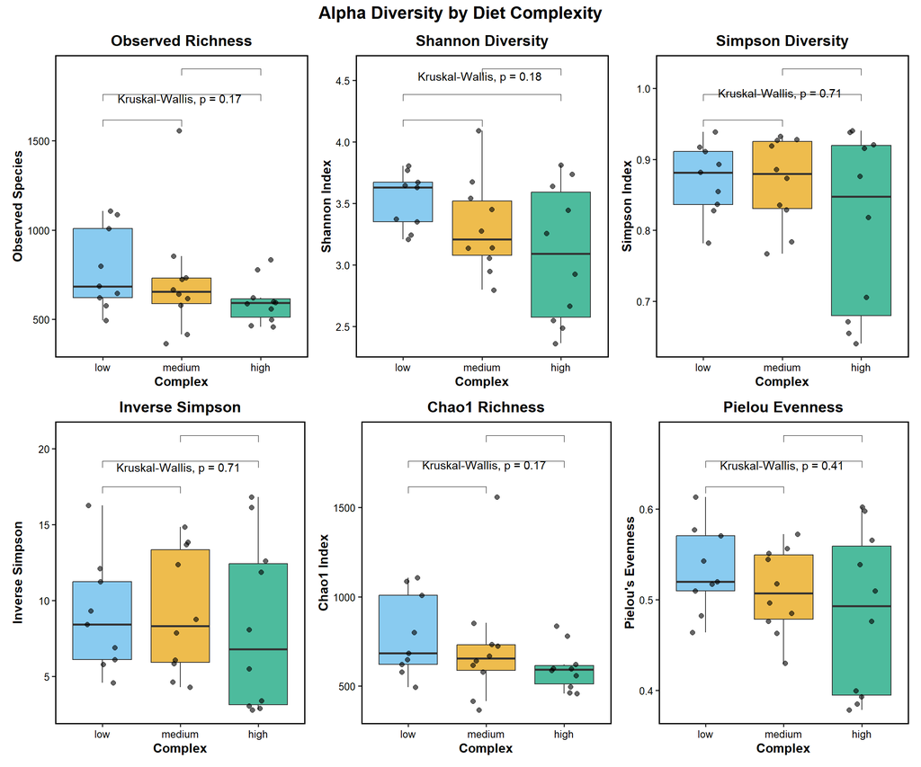

```r
# Pairwise comparisons for complex
comparisons_complex <- list(c("low", "medium"), c("low", "high"), c("medium", "high"))

# Observed richness
p1 <- ggplot(alpha_div, aes(x = complex, y = observed, fill = complex)) +
  geom_boxplot(outlier.shape = NA, alpha = 0.7) +
  geom_jitter(width = 0.2, size = 2, alpha = 0.6) +
  scale_fill_manual(values = complex_colors) +
  stat_compare_means(method = "kruskal.test", label.x = 1.5, label.y = max(alpha_div$observed) * 1.1) +
  stat_compare_means(comparisons = comparisons_complex, method = "wilcox.test",
                     label = "p.signif", hide.ns = TRUE) +
  labs(x = "Complex", y = "Observed Species", title = "Observed Richness") +
  theme_publication +
  theme(legend.position = "none")

# Shannon
p2 <- ggplot(alpha_div, aes(x = complex, y = shannon, fill = complex)) +
  geom_boxplot(outlier.shape = NA, alpha = 0.7) +
  geom_jitter(width = 0.2, size = 2, alpha = 0.6) +
  scale_fill_manual(values = complex_colors) +
  stat_compare_means(method = "kruskal.test", label.x = 1.5, label.y = max(alpha_div$shannon) * 1.1) +
  stat_compare_means(comparisons = comparisons_complex, method = "wilcox.test",
                     label = "p.signif", hide.ns = TRUE) +
  labs(x = "Complex", y = "Shannon Index", title = "Shannon Diversity") +
  theme_publication +
  theme(legend.position = "none")

# Simpson
p3 <- ggplot(alpha_div, aes(x = complex, y = simpson, fill = complex)) +
  geom_boxplot(outlier.shape = NA, alpha = 0.7) +
  geom_jitter(width = 0.2, size = 2, alpha = 0.6) +
  scale_fill_manual(values = complex_colors) +
  stat_compare_means(method = "kruskal.test", label.x = 1.5, label.y = max(alpha_div$simpson) * 1.05) +
  stat_compare_means(comparisons = comparisons_complex, method = "wilcox.test",
                     label = "p.signif", hide.ns = TRUE) +
  labs(x = "Complex", y = "Simpson Index", title = "Simpson Diversity") +
  theme_publication +
  theme(legend.position = "none")

# Inverse Simpson
p4 <- ggplot(alpha_div, aes(x = complex, y = invsimpson, fill = complex)) +
  geom_boxplot(outlier.shape = NA, alpha = 0.7) +
  geom_jitter(width = 0.2, size = 2, alpha = 0.6) +
  scale_fill_manual(values = complex_colors) +
  stat_compare_means(method = "kruskal.test", label.x = 1.5, label.y = max(alpha_div$invsimpson) * 1.1) +
  stat_compare_means(comparisons = comparisons_complex, method = "wilcox.test",
                     label = "p.signif", hide.ns = TRUE) +
  labs(x = "Complex", y = "Inverse Simpson", title = "Inverse Simpson") +
  theme_publication +
  theme(legend.position = "none")

# Chao1
p5 <- ggplot(alpha_div, aes(x = complex, y = chao1, fill = complex)) +
  geom_boxplot(outlier.shape = NA, alpha = 0.7) +
  geom_jitter(width = 0.2, size = 2, alpha = 0.6) +
  scale_fill_manual(values = complex_colors) +
  stat_compare_means(method = "kruskal.test", label.x = 1.5, label.y = max(alpha_div$chao1) * 1.1) +
  stat_compare_means(comparisons = comparisons_complex, method = "wilcox.test",
                     label = "p.signif", hide.ns = TRUE) +
  labs(x = "Complex", y = "Chao1 Index", title = "Chao1 Richness") +
  theme_publication +
  theme(legend.position = "none")

# Pielou evenness
p6 <- ggplot(alpha_div, aes(x = complex, y = pielou, fill = complex)) +
  geom_boxplot(outlier.shape = NA, alpha = 0.7) +
  geom_jitter(width = 0.2, size = 2, alpha = 0.6) +
  scale_fill_manual(values = complex_colors) +
  stat_compare_means(method = "kruskal.test", label.x = 1.5, label.y = max(alpha_div$pielou, na.rm = TRUE) * 1.05) +
  stat_compare_means(comparisons = comparisons_complex, method = "wilcox.test",
                     label = "p.signif", hide.ns = TRUE) +
  labs(x = "Complex", y = "Pielou's Evenness", title = "Pielou Evenness") +
  theme_publication +
  theme(legend.position = "none")

# Combine plots
(p1 | p2 | p3) / (p4 | p5 | p6) +
  plot_annotation(title = "Alpha Diversity by Diet Complexity",
                  theme = theme(plot.title = element_text(hjust = 0.5, face = "bold", size = 16)))
```

#### **Plot alpha diversity by Protease:**

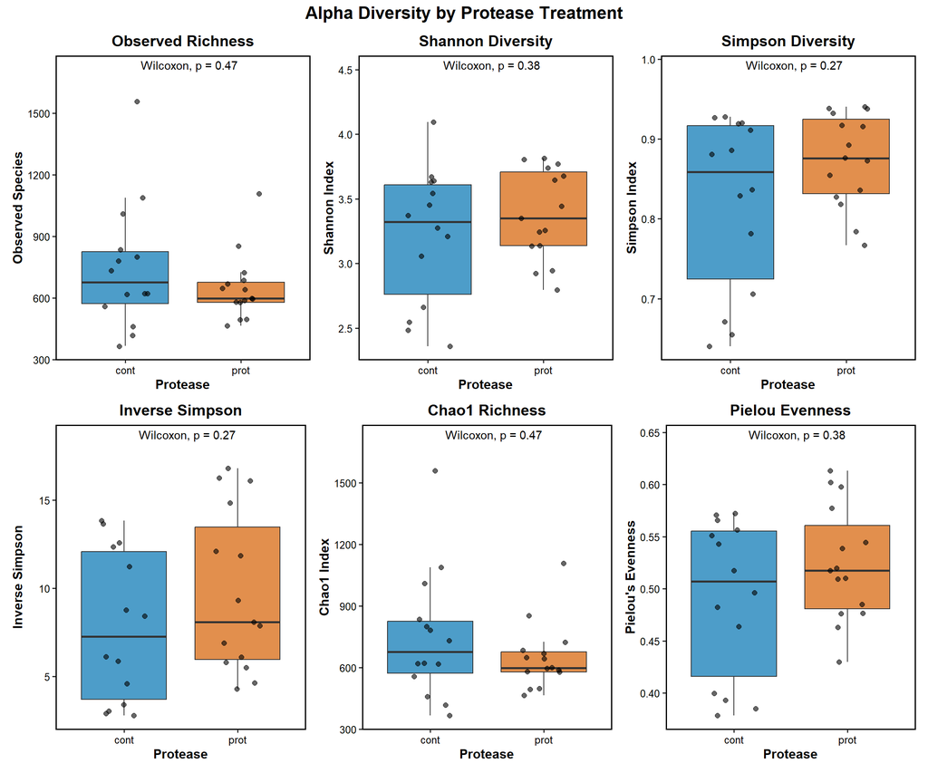

```r
# Observed richness
p1 <- ggplot(alpha_div, aes(x = protease, y = observed, fill = protease)) +
  geom_boxplot(outlier.shape = NA, alpha = 0.7) +
  geom_jitter(width = 0.2, size = 2, alpha = 0.6) +
  scale_fill_manual(values = protease_colors) +
  stat_compare_means(method = "wilcox.test", label.x = 1.3, label.y = max(alpha_div$observed) * 1.1) +
  labs(x = "Protease", y = "Observed Species", title = "Observed Richness") +
  theme_publication +
  theme(legend.position = "none")

# Shannon
p2 <- ggplot(alpha_div, aes(x = protease, y = shannon, fill = protease)) +
  geom_boxplot(outlier.shape = NA, alpha = 0.7) +
  geom_jitter(width = 0.2, size = 2, alpha = 0.6) +
  scale_fill_manual(values = protease_colors) +
  stat_compare_means(method = "wilcox.test", label.x = 1.3, label.y = max(alpha_div$shannon) * 1.1) +
  labs(x = "Protease", y = "Shannon Index", title = "Shannon Diversity") +
  theme_publication +
  theme(legend.position = "none")

# Simpson
p3 <- ggplot(alpha_div, aes(x = protease, y = simpson, fill = protease)) +
  geom_boxplot(outlier.shape = NA, alpha = 0.7) +
  geom_jitter(width = 0.2, size = 2, alpha = 0.6) +
  scale_fill_manual(values = protease_colors) +
  stat_compare_means(method = "wilcox.test", label.x = 1.3, label.y = max(alpha_div$simpson) * 1.05) +
  labs(x = "Protease", y = "Simpson Index", title = "Simpson Diversity") +
  theme_publication +
  theme(legend.position = "none")

# Inverse Simpson
p4 <- ggplot(alpha_div, aes(x = protease, y = invsimpson, fill = protease)) +
  geom_boxplot(outlier.shape = NA, alpha = 0.7) +
  geom_jitter(width = 0.2, size = 2, alpha = 0.6) +
  scale_fill_manual(values = protease_colors) +
  stat_compare_means(method = "wilcox.test", label.x = 1.3, label.y = max(alpha_div$invsimpson) * 1.1) +
  labs(x = "Protease", y = "Inverse Simpson", title = "Inverse Simpson") +
  theme_publication +
  theme(legend.position = "none")

# Chao1
p5 <- ggplot(alpha_div, aes(x = protease, y = chao1, fill = protease)) +
  geom_boxplot(outlier.shape = NA, alpha = 0.7) +
  geom_jitter(width = 0.2, size = 2, alpha = 0.6) +
  scale_fill_manual(values = protease_colors) +
  stat_compare_means(method = "wilcox.test", label.x = 1.3, label.y = max(alpha_div$chao1) * 1.1) +
  labs(x = "Protease", y = "Chao1 Index", title = "Chao1 Richness") +
  theme_publication +
  theme(legend.position = "none")

# Pielou evenness
p6 <- ggplot(alpha_div, aes(x = protease, y = pielou, fill = protease)) +
  geom_boxplot(outlier.shape = NA, alpha = 0.7) +
  geom_jitter(width = 0.2, size = 2, alpha = 0.6) +
  scale_fill_manual(values = protease_colors) +
  stat_compare_means(method = "wilcox.test", label.x = 1.3, label.y = max(alpha_div$pielou, na.rm = TRUE) * 1.05) +
  labs(x = "Protease", y = "Pielou's Evenness", title = "Pielou Evenness") +
  theme_publication +
  theme(legend.position = "none")

# Combine plots
(p1 | p2 | p3) / (p4 | p5 | p6) +
  plot_annotation(title = "Alpha Diversity by Protease Treatment",
                  theme = theme(plot.title = element_text(hjust = 0.5, face = "bold", size = 16)))
```

#### Interaction plot (Complex x Protease):

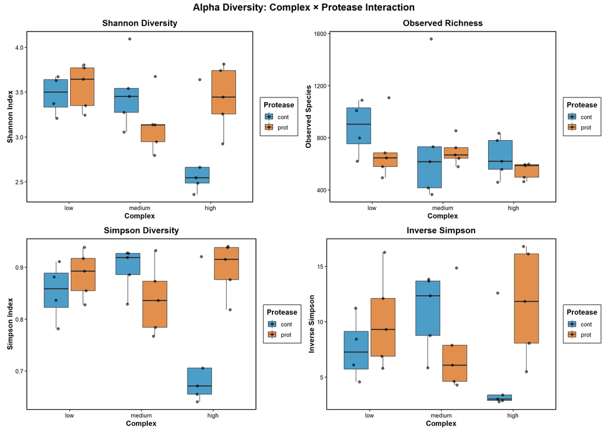

```r
# Shannon by both factors
p1 <- ggplot(alpha_div, aes(x = complex, y = shannon, fill = protease)) +
  geom_boxplot(outlier.shape = NA, alpha = 0.7) +
  geom_point(position = position_jitterdodge(jitter.width = 0.2), size = 2, alpha = 0.6) +
  scale_fill_manual(values = protease_colors) +
  labs(x = "Complex", y = "Shannon Index", fill = "Protease", title = "Shannon Diversity") +
  theme_publication

# Observed by both factors
p2 <- ggplot(alpha_div, aes(x = complex, y = observed, fill = protease)) +
  geom_boxplot(outlier.shape = NA, alpha = 0.7) +
  geom_point(position = position_jitterdodge(jitter.width = 0.2), size = 2, alpha = 0.6) +
  scale_fill_manual(values = protease_colors) +
  labs(x = "Complex", y = "Observed Species", fill = "Protease", title = "Observed Richness") +
  theme_publication

# Chao1 by both factors
p3 <- ggplot(alpha_div, aes(x = complex, y = simpson, fill = protease)) +
  geom_boxplot(outlier.shape = NA, alpha = 0.7) +
  geom_point(position = position_jitterdodge(jitter.width = 0.2), size = 2, alpha = 0.6) +
  scale_fill_manual(values = protease_colors) +
  labs(x = "Complex", y = "Simpson Index", fill = "Protease", title = "Simpson Diversity") +
  theme_publication

# Inverse Simpson by both factors
p4 <- ggplot(alpha_div, aes(x = complex, y = invsimpson, fill = protease)) +
  geom_boxplot(outlier.shape = NA, alpha = 0.7) +
  geom_point(position = position_jitterdodge(jitter.width = 0.2), size = 2, alpha = 0.6) +
  scale_fill_manual(values = protease_colors) +
  labs(x = "Complex", y = "Inverse Simpson", fill = "Protease", title = "Inverse Simpson") +
  theme_publication

(p1 | p2) / (p3 | p4) +
  plot_annotation(title = "Alpha Diversity: Complex × Protease Interaction",
                  theme = theme(plot.title = element_text(hjust = 0.5, face = "bold", size = 16)))
```

#### Two-way ANOVA for interaction effects:

Bruno, aqui tem um coisa para vc decidir e ver em que situação faz mais sentido quando compara com o resultado das outras variaveis do paper (Imuno, desempenho, etc…). Quando a gente usa anova para comparar os tratamentos da significavo, principalmente no Shannon, Simpson index. Onde o grupo protease e complex diet teve maior diversidade que o grupo sem protease e dieta complexa. Mas quando usa o test no-parametrico e com ajuste para false discovery rate, não da significativo. Como estatistico, eu ia para falar que não é diferente. Mas tudo depende do contexto e talvez tem espaço para especular.

```r
# Two-way ANOVA for Shannon
anova_shannon <- aov(shannon ~ complex * protease, data = alpha_div)
summary(anova_shannon)
```

```
                 Df Sum Sq Mean Sq F value Pr(>F)
complex           2 0.8956  0.4478   3.400 0.0509 .
protease          1 0.1626  0.1626   1.235 0.2780
complex:protease  2 1.3666  0.6833   5.188 0.0138 *
Residuals        23 3.0294  0.1317
---
Signif. codes:  0 '***' 0.001 '**' 0.01 '*' 0.05 '.' 0.1 ' ' 1
```

```r
# Two-way ANOVA for Observed
anova_observed <- aov(observed ~ complex * protease, data = alpha_div)
summary(anova_observed)
```

```
                 Df  Sum Sq Mean Sq F value Pr(>F)
complex           2  162028   81014   1.290  0.294
protease          1   79765   79765   1.270  0.271
complex:protease  2   20733   10367   0.165  0.849
Residuals        23 1444460   62803
```

```r
# Two-way ANOVA for simpson
anova_simpson <- aov(simpson ~ complex * protease, data = alpha_div)
summary(anova_simpson)
```

```
                 Df  Sum Sq Mean Sq F value  Pr(>F)
complex           2 0.02484 0.01242   2.673 0.09039 .
protease          1 0.01943 0.01943   4.182 0.05246 .
complex:protease  2 0.07212 0.03606   7.762 0.00265 **
Residuals        23 0.10685 0.00465
---
Signif. codes:  0 '***' 0.001 '**' 0.01 '*' 0.05 '.' 0.1 ' ' 1
```

```r
# Two-way ANOVA for Inverse Simpson
anova_invsimpson <- aov(invsimpson ~ complex * protease, data = alpha_div)
summary(anova_invsimpson)
```

```
                 Df Sum Sq Mean Sq F value Pr(>F)
complex           2    4.5    2.24   0.132 0.8772
protease          1   27.0   27.02   1.593 0.2196
complex:protease  2  127.9   63.96   3.771 0.0383 *
Residuals        23  390.2   16.96
---
Signif. codes:  0 '***' 0.001 '**' 0.01 '*' 0.05 '.' 0.1 ' ' 1
```

```r
# Summary table of interaction effects
interaction_pvalues <- data.frame(
  Metric = c("Shannon", "Observed", "Chao1", "InvSimpson"),
  Complex_p = c(summary(anova_shannon)[[1]]["complex", "Pr(>F)"],
                summary(anova_observed)[[1]]["complex", "Pr(>F)"],
                summary(anova_simpson)[[1]]["complex", "Pr(>F)"],
                summary(anova_invsimpson)[[1]]["complex", "Pr(>F)"]),
  Protease_p = c(summary(anova_shannon)[[1]]["protease", "Pr(>F)"],
                 summary(anova_observed)[[1]]["protease", "Pr(>F)"],
                 summary(anova_simpson)[[1]]["protease", "Pr(>F)"],
                 summary(anova_invsimpson)[[1]]["protease", "Pr(>F)"]),
  Interaction_p = c(summary(anova_shannon)[[1]]["complex:protease", "Pr(>F)"],
                    summary(anova_observed)[[1]]["complex:protease", "Pr(>F)"],
                    summary(anova_simpson)[[1]]["complex:protease", "Pr(>F)"],
                    summary(anova_invsimpson)[[1]]["complex:protease", "Pr(>F)"])
)

kable(interaction_pvalues, digits = 4, caption = "Two-way ANOVA: Complex × Protease effects on Alpha Diversity")
```

Two-way ANOVA: Complex × Protease effects on Alpha Diversity

[output not shown]

**Pairwise comparisons for interaction groups:**

```r
# Pairwise Wilcoxon tests for Shannon
pairwise_shannon <- pairwise.wilcox.test(alpha_div$shannon,
                                          alpha_div$interaction_group,
                                          p.adjust.method = "BH")

# Pairwise Wilcoxon tests for Observed
pairwise_observed <- pairwise.wilcox.test(alpha_div$observed,
                                           alpha_div$interaction_group,
                                           p.adjust.method = "BH")

# Pairwise Wilcoxon tests for Simpson
pairwise_simpson <- pairwise.wilcox.test(alpha_div$simpson,
                                        alpha_div$interaction_group,
                                        p.adjust.method = "BH")

# Pairwise Wilcoxon tests for Inverse Simpson
pairwise_invsimpson <- pairwise.wilcox.test(alpha_div$invsimpson,
                                             alpha_div$interaction_group,
                                             p.adjust.method = "BH")

# Display results
kable(round(pairwise_shannon$p.value, 4), caption = "Pairwise Wilcoxon: Shannon (BH adjusted)")
```

[output not shown]

```r
kable(round(pairwise_observed$p.value, 4), caption = "Pairwise Wilcoxon: Observed (BH adjusted)")
```

[output not shown]

```r
kable(round(pairwise_simpson$p.value, 4), caption = "Pairwise Wilcoxon: Pairwise_simpson (BH adjusted)")
```

[output not shown]

```r
kable(round(pairwise_invsimpson$p.value, 4), caption = "Pairwise Wilcoxon: Inverse Simpson (BH adjusted)")
```

[output not shown]

#### **Plot with interaction groups and pairwise p-values:**

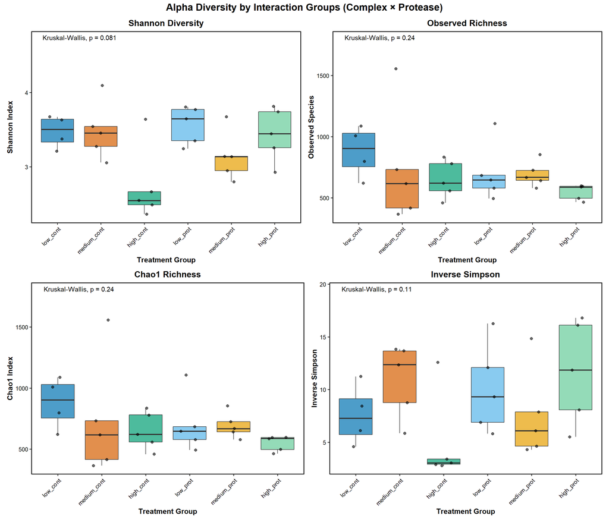

```r
alpha_div$interaction_group <- interaction(alpha_div$complex, alpha_div$protease, sep = "_")

# Colors for interaction groups
interaction_colors <- c(
  "low_cont" = "#0072B2",
  "low_prot" = "#56B4E9",
  "medium_cont" = "#D55E00",
  "medium_prot" = "#E69F00",
  "high_cont" = "#009E73",
  "high_prot" = "#66CC99"
)

# Shannon
p1 <- ggplot(alpha_div, aes(x = interaction_group, y = shannon, fill = interaction_group)) +
  geom_boxplot(outlier.shape = NA, alpha = 0.7) +
  geom_jitter(width = 0.2, size = 2, alpha = 0.6) +
  scale_fill_manual(values = interaction_colors) +
  stat_compare_means(method = "kruskal.test", label.y = max(alpha_div$shannon) * 1.15) +
  labs(x = "Treatment Group", y = "Shannon Index", title = "Shannon Diversity") +
  theme_publication +
  theme(legend.position = "none",
        axis.text.x = element_text(angle = 45, hjust = 1))

# Observed
p2 <- ggplot(alpha_div, aes(x = interaction_group, y = observed, fill = interaction_group)) +
  geom_boxplot(outlier.shape = NA, alpha = 0.7) +
  geom_jitter(width = 0.2, size = 2, alpha = 0.6) +
  scale_fill_manual(values = interaction_colors) +
  stat_compare_means(method = "kruskal.test", label.y = max(alpha_div$observed) * 1.15) +
  labs(x = "Treatment Group", y = "Observed Species", title = "Observed Richness") +
  theme_publication +
  theme(legend.position = "none",
        axis.text.x = element_text(angle = 45, hjust = 1))

# Chao1
p3 <- ggplot(alpha_div, aes(x = interaction_group, y = chao1, fill = interaction_group)) +
  geom_boxplot(outlier.shape = NA, alpha = 0.7) +
  geom_jitter(width = 0.2, size = 2, alpha = 0.6) +
  scale_fill_manual(values = interaction_colors) +
  stat_compare_means(method = "kruskal.test", label.y = max(alpha_div$chao1) * 1.15) +
  labs(x = "Treatment Group", y = "Chao1 Index", title = "Chao1 Richness") +
  theme_publication +
  theme(legend.position = "none",
        axis.text.x = element_text(angle = 45, hjust = 1))

# Inverse Simpson
p4 <- ggplot(alpha_div, aes(x = interaction_group, y = invsimpson, fill = interaction_group)) +
  geom_boxplot(outlier.shape = NA, alpha = 0.7) +
  geom_jitter(width = 0.2, size = 2, alpha = 0.6) +
  scale_fill_manual(values = interaction_colors) +
  stat_compare_means(method = "kruskal.test", label.y = max(alpha_div$invsimpson) * 1.15) +
  labs(x = "Treatment Group", y = "Inverse Simpson", title = "Inverse Simpson") +
  theme_publication +
  theme(legend.position = "none",
        axis.text.x = element_text(angle = 45, hjust = 1))

(p1 | p2) / (p3 | p4) +
  plot_annotation(title = "Alpha Diversity by Interaction Groups (Complex × Protease)",
                  theme = theme(plot.title = element_text(hjust = 0.5, face = "bold", size = 16)))
```

## Beta Diversity Analysis

### Calculate distance matrices:

```r
# Transpose matrix (vegan needs samples as rows)
species_counts_t <- t(species_counts)

# Bray-Curtis distance (abundance-based)
dist_bray <- vegdist(species_counts_t, method = "bray")

# Jaccard distance (presence/absence)
dist_jaccard <- vegdist(species_counts_t, method = "jaccard", binary = TRUE)

# Aitchison distance (compositional - recommended for microbiome)
# Add pseudocount to handle zeros, then CLR transform
species_pseudo <- species_counts_t + 1
species_clr <- log(species_pseudo) - rowMeans(log(species_pseudo))
dist_aitchison <- vegdist(species_clr, method = "euclidean")
```

#### PERMANOVA - Main effects Complex:

```r
# Bray-Curtis PERMANOVA
set.seed(123)
permanova_bray_complex <- adonis2(dist_bray ~ complex,
                          data = meta_tab,
                          permutations = 999)

# Jaccard PERMANOVA
set.seed(123)
permanova_jaccard_complex <- adonis2(dist_jaccard ~ complex,
                             data = meta_tab,
                             permutations = 999)

# Aitchison PERMANOVA
set.seed(123)
permanova_aitchison_complex <- adonis2(dist_aitchison ~ complex,
                               data = meta_tab,
                               permutations = 999)

# Display results
kable(permanova_bray_complex, digits = 4, caption = "PERMANOVA: Bray-Curtis Distance")
```

PERMANOVA: Bray-Curtis Distance

|  | Df | SumOfSqs | R2 | F | Pr(>F) |
| --- | --- | --- | --- | --- | --- |
| Model | 2 | 0.1687 | 0.052 | 0.7134 | 0.752 |
| Residual | 26 | 3.0740 | 0.948 | NA | NA |
| Total | 28 | 3.2427 | 1.000 | NA | NA |

```r
kable(permanova_jaccard_complex, digits = 4, caption = "PERMANOVA: Jaccard Distance")
```

PERMANOVA: Jaccard Distance

|  | Df | SumOfSqs | R2 | F | Pr(>F) |
| --- | --- | --- | --- | --- | --- |
| Model | 2 | 0.2946 | 0.0844 | 1.1979 | 0.186 |
| Residual | 26 | 3.1968 | 0.9156 | NA | NA |
| Total | 28 | 3.4913 | 1.0000 | NA | NA |

```r
kable(permanova_aitchison_complex, digits = 4, caption = "PERMANOVA: Aitchison Distance")
```

PERMANOVA: Aitchison Distance

|  | Df | SumOfSqs | R2 | F | Pr(>F) |
| --- | --- | --- | --- | --- | --- |
| Model | 2 | 6124.551 | 0.074 | 1.0396 | 0.325 |
| Residual | 26 | 76583.809 | 0.926 | NA | NA |
| Total | 28 | 82708.360 | 1.000 | NA | NA |

#### PERMANOVA - Main effects Protease:

```r
# Bray-Curtis PERMANOVA
set.seed(123)
permanova_bray_protease <- adonis2(dist_bray ~  protease,
                          data = meta_tab,
                          permutations = 999)

# Jaccard PERMANOVA
set.seed(123)
permanova_jaccard_protease <- adonis2(dist_jaccard ~ protease,
                             data = meta_tab,
                             permutations = 999)

# Aitchison PERMANOVA
set.seed(123)
permanova_aitchison_protease <- adonis2(dist_aitchison ~ protease,
                               data = meta_tab,
                               permutations = 999)

# Display results
kable(permanova_bray_protease, digits = 4, caption = "PERMANOVA: Bray-Curtis Distance")
```

PERMANOVA: Bray-Curtis Distance

|  | Df | SumOfSqs | R2 | F | Pr(>F) |
| --- | --- | --- | --- | --- | --- |
| Model | 1 | 0.1223 | 0.0377 | 1.0585 | 0.338 |
| Residual | 27 | 3.1204 | 0.9623 | NA | NA |
| Total | 28 | 3.2427 | 1.0000 | NA | NA |

```r
kable(permanova_jaccard_protease, digits = 4, caption = "PERMANOVA: Jaccard Distance")
```

PERMANOVA: Jaccard Distance

|  | Df | SumOfSqs | R2 | F | Pr(>F) |
| --- | --- | --- | --- | --- | --- |
| Model | 1 | 0.1070 | 0.0307 | 0.8537 | 0.618 |
| Residual | 27 | 3.3843 | 0.9693 | NA | NA |
| Total | 28 | 3.4913 | 1.0000 | NA | NA |

```r
kable(permanova_aitchison_protease, digits = 4, caption = "PERMANOVA: Aitchison Distance")
```

PERMANOVA: Aitchison Distance

|  | Df | SumOfSqs | R2 | F | Pr(>F) |
| --- | --- | --- | --- | --- | --- |
| Model | 1 | 2550.817 | 0.0308 | 0.8592 | 0.678 |
| Residual | 27 | 80157.543 | 0.9692 | NA | NA |
| Total | 28 | 82708.360 | 1.0000 | NA | NA |

#### PERMANOVA - Interaction:

```r
# Bray-Curtis PERMANOVA
set.seed(123)
permanova_bray_interaction <- adonis2(dist_bray ~ complex * protease,
                          data = meta_tab,
                          permutations = 999)

# Jaccard PERMANOVA
set.seed(123)
permanova_jaccard_interaction <- adonis2(dist_jaccard ~ complex * protease,
                             data = meta_tab,
                             permutations = 999)

# Aitchison PERMANOVA
set.seed(123)
permanova_aitchison_interaction <- adonis2(dist_aitchison ~ complex * protease,
                               data = meta_tab,
                               permutations = 999)

# Display results
kable(permanova_bray_interaction, digits = 4, caption = "PERMANOVA: Bray-Curtis Distance")
```

PERMANOVA: Bray-Curtis Distance

|  | Df | SumOfSqs | R2 | F | Pr(>F) |
| --- | --- | --- | --- | --- | --- |
| Model | 5 | 0.6279 | 0.1936 | 1.1047 | 0.315 |
| Residual | 23 | 2.6148 | 0.8064 | NA | NA |
| Total | 28 | 3.2427 | 1.0000 | NA | NA |

```r
kable(permanova_jaccard_interaction, digits = 4, caption = "PERMANOVA: Jaccard Distance")
```

PERMANOVA: Jaccard Distance

|  | Df | SumOfSqs | R2 | F | Pr(>F) |
| --- | --- | --- | --- | --- | --- |
| Model | 5 | 0.7293 | 0.2089 | 1.2146 | 0.094 |
| Residual | 23 | 2.7621 | 0.7911 | NA | NA |
| Total | 28 | 3.4913 | 1.0000 | NA | NA |

```r
kable(permanova_aitchison_interaction, digits = 4, caption = "PERMANOVA: Aitchison Distance")
```

PERMANOVA: Aitchison Distance

|  | Df | SumOfSqs | R2 | F | Pr(>F) |
| --- | --- | --- | --- | --- | --- |
| Model | 5 | 16513.65 | 0.1997 | 1.1476 | 0.11 |
| Residual | 23 | 66194.71 | 0.8003 | NA | NA |
| Total | 28 | 82708.36 | 1.0000 | NA | NA |

#### **Pairwise PERMANOVA for Complex:**

```r
# Pairwise PERMANOVA for complex (Bray-Curtis)
set.seed(123)
pairwise_complex_bray <- pairwise.adonis(dist_bray,
                                          factors = meta_tab$complex,
                                          p.adjust.m = "BH",
                                          perm = 999)

# Pairwise PERMANOVA for complex (Jaccard)
set.seed(123)
pairwise_complex_jaccard <- pairwise.adonis(dist_jaccard,
                                             factors = meta_tab$complex,
                                             p.adjust.m = "BH",
                                             perm = 999)

# Pairwise PERMANOVA for complex (Aitchison)
set.seed(123)
pairwise_complex_aitchison <- pairwise.adonis(dist_aitchison,
                                               factors = meta_tab$complex,
                                               p.adjust.m = "BH",
                                               perm = 999)

kable(pairwise_complex_bray, digits = 4, caption = "Pairwise PERMANOVA (Bray-Curtis): Complex")
```

Pairwise PERMANOVA (Bray-Curtis): Complex

| pairs | Df | SumsOfSqs | F.Model | R2 | p.value | p.adjusted | sig |
| --- | --- | --- | --- | --- | --- | --- | --- |
| low vs high | 1 | 0.0778 | 0.6172 | 0.0350 | 0.717 | 0.717 |  |
| low vs medium | 1 | 0.0852 | 0.7355 | 0.0415 | 0.625 | 0.717 |  |
| high vs medium | 1 | 0.0897 | 0.7937 | 0.0422 | 0.581 | 0.717 |  |

```r
kable(pairwise_complex_jaccard, digits = 4, caption = "Pairwise PERMANOVA (Jaccard): Complex")
```

Pairwise PERMANOVA (Jaccard): Complex

| pairs | Df | SumsOfSqs | F.Model | R2 | p.value | p.adjusted | sig |
| --- | --- | --- | --- | --- | --- | --- | --- |
| low vs high | 1 | 0.1781 | 1.4958 | 0.0809 | 0.085 | 0.255 |  |
| low vs medium | 1 | 0.1603 | 1.1805 | 0.0649 | 0.238 | 0.357 |  |
| high vs medium | 1 | 0.1056 | 0.9226 | 0.0488 | 0.491 | 0.491 |  |

```r
kable(pairwise_complex_aitchison, digits = 4, caption = "Pairwise PERMANOVA (Aitchison): Complex")
```

Pairwise PERMANOVA (Aitchison): Complex

| pairs | Df | SumsOfSqs | F.Model | R2 | p.value | p.adjusted | sig |
| --- | --- | --- | --- | --- | --- | --- | --- |
| low vs high | 1 | 3140.138 | 1.0691 | 0.0592 | 0.296 | 0.444 |  |
| low vs medium | 1 | 3638.287 | 1.1352 | 0.0626 | 0.223 | 0.444 |  |
| high vs medium | 1 | 2441.095 | 0.9013 | 0.0477 | 0.574 | 0.574 |  |

#### **Pairwise PERMANOVA for Interaction groups:**

Aqui mais uma vez, nao deu significativo quando ajusta para fdr mas é significativo só com o p value.

```r
# Create interaction group
meta_tab$interaction_group <- interaction(meta_tab$complex, meta_tab$protease, sep = "_")

# Pairwise PERMANOVA for interaction (Bray-Curtis)
set.seed(123)
pairwise_interaction_bray <- pairwise.adonis(dist_bray,
                                              factors = meta_tab$interaction_group,
                                              p.adjust.m = "BH",
                                              perm = 999)

# Pairwise PERMANOVA for interaction (Aitchison)
set.seed(123)
pairwise_interaction_aitchison <- pairwise.adonis(dist_aitchison,
                                                   factors = meta_tab$interaction_group,
                                                   p.adjust.m = "BH",
                                                   perm = 999)

# Pairwise PERMANOVA for interaction (jaccard)
set.seed(123)
pairwise_interaction_jaccard <- pairwise.adonis(dist_jaccard,
                                                   factors = meta_tab$interaction_group,
                                                   p.adjust.m = "BH",
                                                   perm = 999)

kable(pairwise_interaction_bray, digits = 4, caption = "Pairwise PERMANOVA (Bray-Curtis): Interaction Groups")
```

Pairwise PERMANOVA (Bray-Curtis): Interaction Groups

| pairs | Df | SumsOfSqs | F.Model | R2 | p.value | p.adjusted | sig |
| --- | --- | --- | --- | --- | --- | --- | --- |
| low_prot vs high_cont | 1 | 0.2204 | 1.5607 | 0.1632 | 0.164 | 0.5250 |  |
| low_prot vs low_cont | 1 | 0.0885 | 0.6517 | 0.0852 | 0.637 | 0.7962 |  |
| low_prot vs medium_cont | 1 | 0.0590 | 0.3904 | 0.0465 | 0.970 | 0.9700 |  |
| low_prot vs high_prot | 1 | 0.0805 | 0.5387 | 0.0631 | 0.837 | 0.8968 |  |
| low_prot vs medium_prot | 1 | 0.1313 | 0.9259 | 0.1037 | 0.475 | 0.7800 |  |
| high_cont vs low_cont | 1 | 0.0669 | 0.8083 | 0.1035 | 0.540 | 0.7800 |  |
| high_cont vs medium_cont | 1 | 0.2043 | 1.9548 | 0.1964 | 0.106 | 0.5250 |  |
| high_cont vs high_prot | 1 | 0.2808 | 2.7288 | 0.2543 | 0.063 | 0.5250 |  |
| high_cont vs medium_prot | 1 | 0.0830 | 0.8712 | 0.0982 | 0.566 | 0.7800 |  |
| low_cont vs medium_cont | 1 | 0.0912 | 0.9708 | 0.1218 | 0.379 | 0.7800 |  |
| low_cont vs high_prot | 1 | 0.1423 | 1.5451 | 0.1808 | 0.175 | 0.5250 |  |
| low_cont vs medium_prot | 1 | 0.0657 | 0.7883 | 0.1012 | 0.572 | 0.7800 |  |
| medium_cont vs high_prot | 1 | 0.0875 | 0.7761 | 0.0884 | 0.707 | 0.8158 |  |
| medium_cont vs medium_prot | 1 | 0.0899 | 0.8558 | 0.0966 | 0.539 | 0.7800 |  |
| high_prot vs medium_prot | 1 | 0.1753 | 1.6948 | 0.1748 | 0.112 | 0.5250 |  |

```r
kable(pairwise_interaction_aitchison, digits = 4, caption = "Pairwise PERMANOVA (Aitchison): Interaction Groups")
```

Pairwise PERMANOVA (Aitchison): Interaction Groups

| pairs | Df | SumsOfSqs | F.Model | R2 | p.value | p.adjusted | sig |
| --- | --- | --- | --- | --- | --- | --- | --- |
| low_prot vs high_cont | 1 | 3967.394 | 1.2938 | 0.1392 | 0.149 | 0.2794 |  |
| low_prot vs low_cont | 1 | 3131.294 | 0.8873 | 0.1125 | 0.629 | 0.7862 |  |
| low_prot vs medium_cont | 1 | 2896.079 | 0.8147 | 0.0924 | 0.735 | 0.8481 |  |
| low_prot vs high_prot | 1 | 2285.441 | 0.7395 | 0.0846 | 0.888 | 0.8880 |  |
| low_prot vs medium_prot | 1 | 3825.103 | 1.2344 | 0.1337 | 0.171 | 0.2850 |  |
| high_cont vs low_cont | 1 | 3411.929 | 1.2746 | 0.1540 | 0.131 | 0.2794 |  |
| high_cont vs medium_cont | 1 | 4005.985 | 1.4260 | 0.1513 | 0.090 | 0.2794 |  |
| high_cont vs high_prot | 1 | 3338.691 | 1.4239 | 0.1511 | 0.118 | 0.2794 |  |
| high_cont vs medium_prot | 1 | 2104.903 | 0.8945 | 0.1006 | 0.595 | 0.7862 |  |
| low_cont vs medium_cont | 1 | 3824.584 | 1.1822 | 0.1445 | 0.116 | 0.2794 |  |
| low_cont vs high_prot | 1 | 3087.564 | 1.1417 | 0.1402 | 0.191 | 0.2865 |  |
| low_cont vs medium_prot | 1 | 3786.593 | 1.3953 | 0.1662 | 0.070 | 0.2794 |  |
| medium_cont vs high_prot | 1 | 2465.594 | 0.8702 | 0.0981 | 0.802 | 0.8593 |  |
| medium_cont vs medium_prot | 1 | 3919.112 | 1.3792 | 0.1470 | 0.056 | 0.2794 |  |
| high_prot vs medium_prot | 1 | 3563.510 | 1.4991 | 0.1578 | 0.064 | 0.2794 |  |

```r
kable(pairwise_interaction_jaccard, digits = 4, caption = "Pairwise PERMANOVA (Jaccard): Interaction Groups")
```

Pairwise PERMANOVA (Jaccard): Interaction Groups

| pairs | Df | SumsOfSqs | F.Model | R2 | p.value | p.adjusted | sig |
| --- | --- | --- | --- | --- | --- | --- | --- |
| low_prot vs high_cont | 1 | 0.1714 | 1.3512 | 0.1445 | 0.182 | 0.3412 |  |
| low_prot vs low_cont | 1 | 0.1342 | 0.9374 | 0.1181 | 0.473 | 0.6450 |  |
| low_prot vs medium_cont | 1 | 0.1264 | 0.7531 | 0.0860 | 0.726 | 0.7260 |  |
| low_prot vs high_prot | 1 | 0.1210 | 0.9035 | 0.1015 | 0.579 | 0.7237 |  |
| low_prot vs medium_prot | 1 | 0.1678 | 1.3521 | 0.1446 | 0.147 | 0.3412 |  |
| high_cont vs low_cont | 1 | 0.1490 | 1.5206 | 0.1785 | 0.096 | 0.3412 |  |
| high_cont vs medium_cont | 1 | 0.1532 | 1.1941 | 0.1299 | 0.222 | 0.3700 |  |
| high_cont vs high_prot | 1 | 0.1321 | 1.3982 | 0.1488 | 0.159 | 0.3412 |  |
| high_cont vs medium_prot | 1 | 0.0716 | 0.8458 | 0.0956 | 0.686 | 0.7260 |  |
| low_cont vs medium_cont | 1 | 0.1741 | 1.2022 | 0.1466 | 0.258 | 0.3870 |  |
| low_cont vs high_prot | 1 | 0.1832 | 1.7262 | 0.1978 | 0.024 | 0.2700 |  |
| low_cont vs medium_prot | 1 | 0.1551 | 1.6352 | 0.1894 | 0.054 | 0.2700 |  |
| medium_cont vs high_prot | 1 | 0.1182 | 0.8725 | 0.0983 | 0.646 | 0.7260 |  |
| medium_cont vs medium_prot | 1 | 0.1685 | 1.3418 | 0.1436 | 0.179 | 0.3412 |  |
| high_prot vs medium_prot | 1 | 0.1689 | 1.8414 | 0.1871 | 0.038 | 0.2700 |  |

#### **Betadisper - Test for homogeneity of dispersions:**

```r
# Betadisper for Complex (Bray-Curtis)
betadisp_complex_bray <- betadisper(dist_bray, meta_tab$complex)
permutest_complex_bray <- permutest(betadisp_complex_bray, pairwise = TRUE, permutations = 999)

# Betadisper for Protease (Bray-Curtis)
betadisp_protease_bray <- betadisper(dist_bray, meta_tab$protease)
permutest_protease_bray <- permutest(betadisp_protease_bray, pairwise = TRUE, permutations = 999)

# Betadisper for Interaction (Bray-Curtis)
betadisp_interaction_bray <- betadisper(dist_bray, meta_tab$interaction_group)
permutest_interaction_bray <- permutest(betadisp_interaction_bray, pairwise = TRUE, permutations = 999)

# Display results
print("Betadisper - Complex (Bray-Curtis):")
```

```
[1] "Betadisper - Complex (Bray-Curtis):"
```

```r
permutest_complex_bray
```

```
Permutation test for homogeneity of multivariate dispersions
Permutation: free
Number of permutations: 999

Response: Distances
          Df  Sum Sq   Mean Sq     F N.Perm Pr(>F)
Groups     2 0.00250 0.0012500 0.129    999  0.885
Residuals 26 0.25201 0.0096926

Pairwise comparisons:
(Observed p-value below diagonal, permuted p-value above diagonal)
           low  medium  high
low            0.66700 0.991
medium 0.65814         0.595
high   0.98528 0.61037
```

```r
print("Betadisper - Protease (Bray-Curtis):")
```

```
[1] "Betadisper - Protease (Bray-Curtis):"
```

```r
permutest_protease_bray
```

```
Permutation test for homogeneity of multivariate dispersions
Permutation: free
Number of permutations: 999

Response: Distances
          Df   Sum Sq   Mean Sq      F N.Perm Pr(>F)
Groups     1 0.017266 0.0172655 2.1828    999  0.149
Residuals 27 0.213563 0.0079097

Pairwise comparisons:
(Observed p-value below diagonal, permuted p-value above diagonal)
        cont  prot
cont         0.145
prot 0.15113
```

```r
print("Betadisper - Interaction (Bray-Curtis):")
```

```
[1] "Betadisper - Interaction (Bray-Curtis):"
```

```r
permutest_interaction_bray
```

```
Permutation test for homogeneity of multivariate dispersions
Permutation: free
Number of permutations: 999

Response: Distances
          Df   Sum Sq  Mean Sq      F N.Perm Pr(>F)
Groups     5 0.071232 0.014246 1.3838    999  0.261
Residuals 23 0.236783 0.010295

Pairwise comparisons:
(Observed p-value below diagonal, permuted p-value above diagonal)
            low_cont medium_cont high_cont low_prot medium_prot high_prot
low_cont                0.109000  0.756000 0.023000    0.386000     0.244
medium_cont 0.102469              0.523000 0.193000    0.588000     0.907
high_cont   0.744547    0.526898           0.139000    0.799000     0.629
low_prot    0.028352    0.181411  0.149135             0.109000     0.198
medium_prot 0.392253    0.579271  0.811412 0.111140                 0.730
high_prot   0.246693    0.888172  0.622215 0.199405    0.726144
```

#### PCoA ordination:

```r
# PCoA on Bray-Curtis
pcoa_bray <- cmdscale(dist_bray, k = 3, eig = TRUE)

# Calculate variance explained
var_explained_bray <- round(pcoa_bray$eig / sum(pcoa_bray$eig) * 100, 2)

# Create data frame for plotting
pcoa_bray_df <- data.frame(
  sample = rownames(pcoa_bray$points),
  PC1 = pcoa_bray$points[, 1],
  PC2 = pcoa_bray$points[, 2],
  PC3 = pcoa_bray$points[, 3]
)
pcoa_bray_df <- merge(pcoa_bray_df, meta_tab, by.x = "sample", by.y = "row.names")

# PCoA on Aitchison
pcoa_aitchison <- cmdscale(dist_aitchison, k = 3, eig = TRUE)
var_explained_aitchison <- round(pcoa_aitchison$eig / sum(pcoa_aitchison$eig) * 100, 2)

pcoa_aitchison_df <- data.frame(
  sample = rownames(pcoa_aitchison$points),
  PC1 = pcoa_aitchison$points[, 1],
  PC2 = pcoa_aitchison$points[, 2],
  PC3 = pcoa_aitchison$points[, 3]
)
pcoa_aitchison_df <- merge(pcoa_aitchison_df, meta_tab, by.x = "sample", by.y = "row.names")
```

#### PCoA plot by Complex:

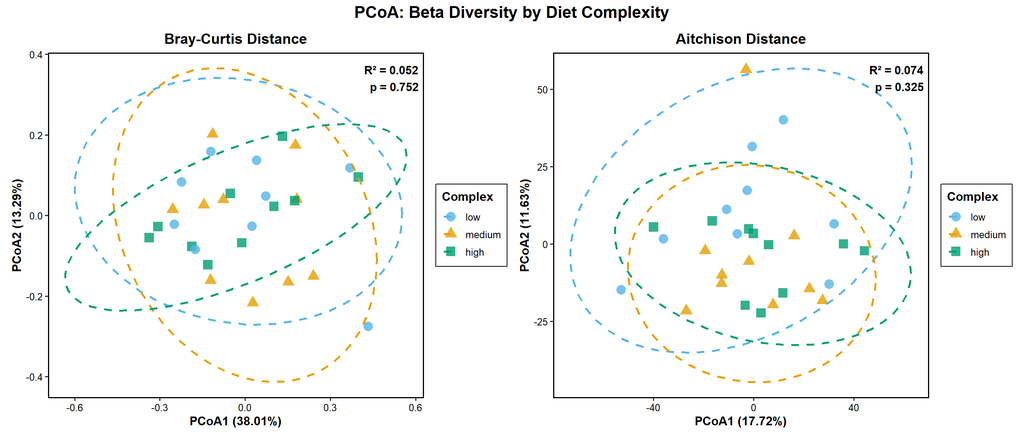

```r
# Extract PERMANOVA stats for annotation
r2_complex_bray <- round(permanova_bray_complex["Model", "R2"], 3)
p_complex_bray <- permanova_bray_complex["Model", "Pr(>F)"]
p_label_bray <- ifelse(p_complex_bray < 0.001, "p < 0.001", paste0("p = ", round(p_complex_bray, 3)))

r2_complex_aitchison <- round(permanova_aitchison_complex["Model", "R2"], 3)
p_complex_aitchison <- permanova_aitchison_complex["Model", "Pr(>F)"]
p_label_aitchison <- ifelse(p_complex_aitchison < 0.001, "p < 0.001", paste0("p = ", round(p_complex_aitchison, 3)))

# Bray-Curtis PCoA
p1 <- ggplot(pcoa_bray_df, aes(x = PC1, y = PC2, color = complex, shape = complex)) +
  geom_point(size = 4, alpha = 0.8) +
  stat_ellipse(level = 0.95, linetype = "dashed", linewidth = 1) +
  scale_color_manual(values = complex_colors) +
  labs(
    x = paste0("PCoA1 (", var_explained_bray[1], "%)"),
    y = paste0("PCoA2 (", var_explained_bray[2], "%)"),
    color = "Complex",
    shape = "Complex",
    title = "Bray-Curtis Distance"
  ) +
  annotate("text", x = Inf, y = Inf,
           label = paste0("R² = ", r2_complex_bray, "\n", p_label_bray),
           hjust = 1.1, vjust = 1.5, size = 4, fontface = "bold") +
  theme_publication

# Aitchison PCoA
p2 <- ggplot(pcoa_aitchison_df, aes(x = PC1, y = PC2, color = complex, shape = complex)) +
  geom_point(size = 4, alpha = 0.8) +
  stat_ellipse(level = 0.95, linetype = "dashed", linewidth = 1) +
  scale_color_manual(values = complex_colors) +
  labs(
    x = paste0("PCoA1 (", var_explained_aitchison[1], "%)"),
    y = paste0("PCoA2 (", var_explained_aitchison[2], "%)"),
    color = "Complex",
    shape = "Complex",
    title = "Aitchison Distance"
  ) +
  annotate("text", x = Inf, y = Inf,
           label = paste0("R² = ", r2_complex_aitchison, "\n", p_label_aitchison),
           hjust = 1.1, vjust = 1.5, size = 4, fontface = "bold") +
  theme_publication

p1 + p2 +
  plot_annotation(title = "PCoA: Beta Diversity by Diet Complexity",
                  theme = theme(plot.title = element_text(hjust = 0.5, face = "bold", size = 16)))
```

#### PCoA plot by Protease:

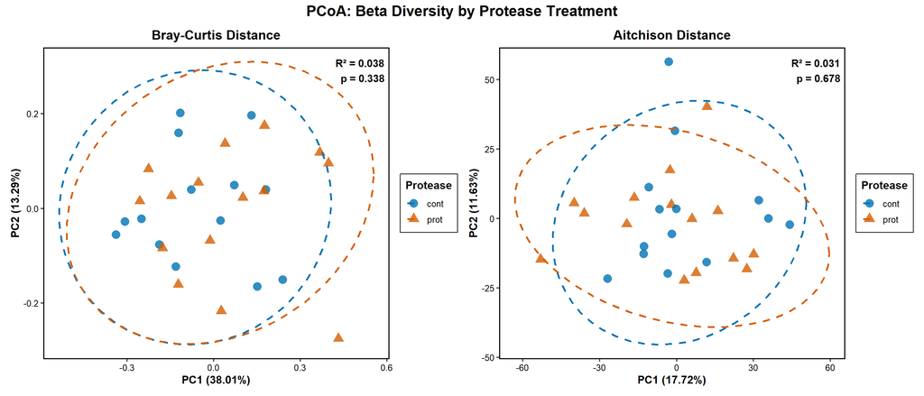

```r
# Extract PERMANOVA stats
r2_protease_bray <- round(permanova_bray_protease["Model", "R2"], 3)
p_protease_bray <- permanova_bray_protease["Model", "Pr(>F)"]
p_label_bray <- ifelse(p_protease_bray < 0.001, "p < 0.001", paste0("p = ", round(p_protease_bray, 3)))

r2_protease_aitchison <- round(permanova_aitchison_protease["Model", "R2"], 3)
p_protease_aitchison <- permanova_aitchison_protease["Model", "Pr(>F)"]
p_label_aitchison <- ifelse(p_protease_aitchison < 0.001, "p < 0.001", paste0("p = ", round(p_protease_aitchison, 3)))

# Bray-Curtis PCoA
p1 <- ggplot(pcoa_bray_df, aes(x = PC1, y = PC2, color = protease, shape = protease)) +
  geom_point(size = 4, alpha = 0.8) +
  stat_ellipse(level = 0.95, linetype = "dashed", linewidth = 1) +
  scale_color_manual(values = protease_colors) +
  labs(
    x = paste0("PC1 (", var_explained_bray[1], "%)"),
    y = paste0("PC2 (", var_explained_bray[2], "%)"),
    color = "Protease",
    shape = "Protease",
    title = "Bray-Curtis Distance"
  ) +
  annotate("text", x = Inf, y = Inf,
           label = paste0("R² = ", r2_protease_bray, "\n", p_label_bray),
           hjust = 1.1, vjust = 1.5, size = 4, fontface = "bold") +
  theme_publication

# Aitchison PCoA
p2 <- ggplot(pcoa_aitchison_df, aes(x = PC1, y = PC2, color = protease, shape = protease)) +
  geom_point(size = 4, alpha = 0.8) +
  stat_ellipse(level = 0.95, linetype = "dashed", linewidth = 1) +
  scale_color_manual(values = protease_colors) +
  labs(
    x = paste0("PC1 (", var_explained_aitchison[1], "%)"),
    y = paste0("PC2 (", var_explained_aitchison[2], "%)"),
    color = "Protease",
    shape = "Protease",
    title = "Aitchison Distance"
  ) +
  annotate("text", x = Inf, y = Inf,
           label = paste0("R² = ", r2_protease_aitchison, "\n", p_label_aitchison),
           hjust = 1.1, vjust = 1.5, size = 4, fontface = "bold") +
  theme_publication

p1 + p2 +
  plot_annotation(title = "PCoA: Beta Diversity by Protease Treatment",
                  theme = theme(plot.title = element_text(hjust = 0.5, face = "bold", size = 16)))
```

#### PCoA plot by Interaction (Complex x Protease):

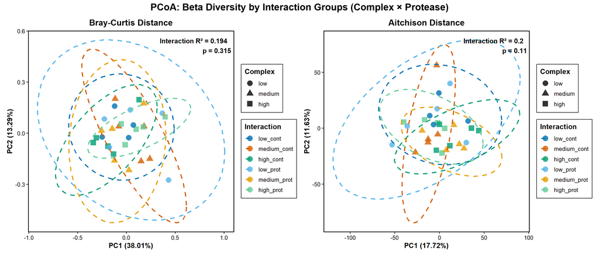

```r
# Extract interaction PERMANOVA stats
r2_interaction_bray <- round(permanova_bray_interaction["Model", "R2"], 3)
p_interaction_bray <- permanova_bray_interaction["Model", "Pr(>F)"]
p_label_bray <- ifelse(p_interaction_bray < 0.001, "p < 0.001", paste0("p = ", round(p_interaction_bray, 3)))

r2_interaction_aitchison <- round(permanova_aitchison_interaction["Model", "R2"], 3)
p_interaction_aitchison <- permanova_aitchison_interaction["Model", "Pr(>F)"]
p_label_aitchison <- ifelse(p_interaction_aitchison < 0.001, "p < 0.001", paste0("p = ", round(p_interaction_aitchison, 3)))

# Colors for interaction groups
interaction_colors <- c(
  "low_cont" = "#0072B2",
  "low_prot" = "#56B4E9",
  "medium_cont" = "#D55E00",
  "medium_prot" = "#E69F00",
  "high_cont" = "#009E73",
  "high_prot" = "#66CC99"
)

# Create interaction variable in pcoa dataframes
pcoa_bray_df$interaction_group <- interaction(pcoa_bray_df$complex, pcoa_bray_df$protease, sep = "_")
pcoa_aitchison_df$interaction_group <- interaction(pcoa_aitchison_df$complex, pcoa_aitchison_df$protease, sep = "_")

# Bray-Curtis PCoA
p1 <- ggplot(pcoa_bray_df, aes(x = PC1, y = PC2, color = interaction_group, shape = complex)) +
  geom_point(size = 4, alpha = 0.8) +
  stat_ellipse(aes(group = interaction_group), level = 0.95, linetype = "dashed", linewidth = 1) +
  scale_color_manual(values = interaction_colors) +
  labs(
    x = paste0("PC1 (", var_explained_bray[1], "%)"),
    y = paste0("PC2 (", var_explained_bray[2], "%)"),
    color = "Interaction",
    shape = "Complex",
    title = "Bray-Curtis Distance"
  ) +
  annotate("text", x = Inf, y = Inf,
           label = paste0("Interaction R² = ", r2_interaction_bray, "\n", p_label_bray),
           hjust = 1.1, vjust = 1.5, size = 4, fontface = "bold") +
  theme_publication

# Aitchison PCoA
p2 <- ggplot(pcoa_aitchison_df, aes(x = PC1, y = PC2, color = interaction_group, shape = complex)) +
  geom_point(size = 4, alpha = 0.8) +
  stat_ellipse(aes(group = interaction_group), level = 0.95, linetype = "dashed", linewidth = 1) +
  scale_color_manual(values = interaction_colors) +
  labs(
    x = paste0("PC1 (", var_explained_aitchison[1], "%)"),
    y = paste0("PC2 (", var_explained_aitchison[2], "%)"),
    color = "Interaction",
    shape = "Complex",
    title = "Aitchison Distance"
  ) +
  annotate("text", x = Inf, y = Inf,
           label = paste0("Interaction R² = ", r2_interaction_aitchison, "\n", p_label_aitchison),
           hjust = 1.1, vjust = 1.5, size = 4, fontface = "bold") +
  theme_publication

p1 + p2 +
  plot_annotation(title = "PCoA: Beta Diversity by Interaction Groups (Complex × Protease)",
                  theme = theme(plot.title = element_text(hjust = 0.5, face = "bold", size = 16)))
```

#### Combined PCoA plot (all factors in one figure):

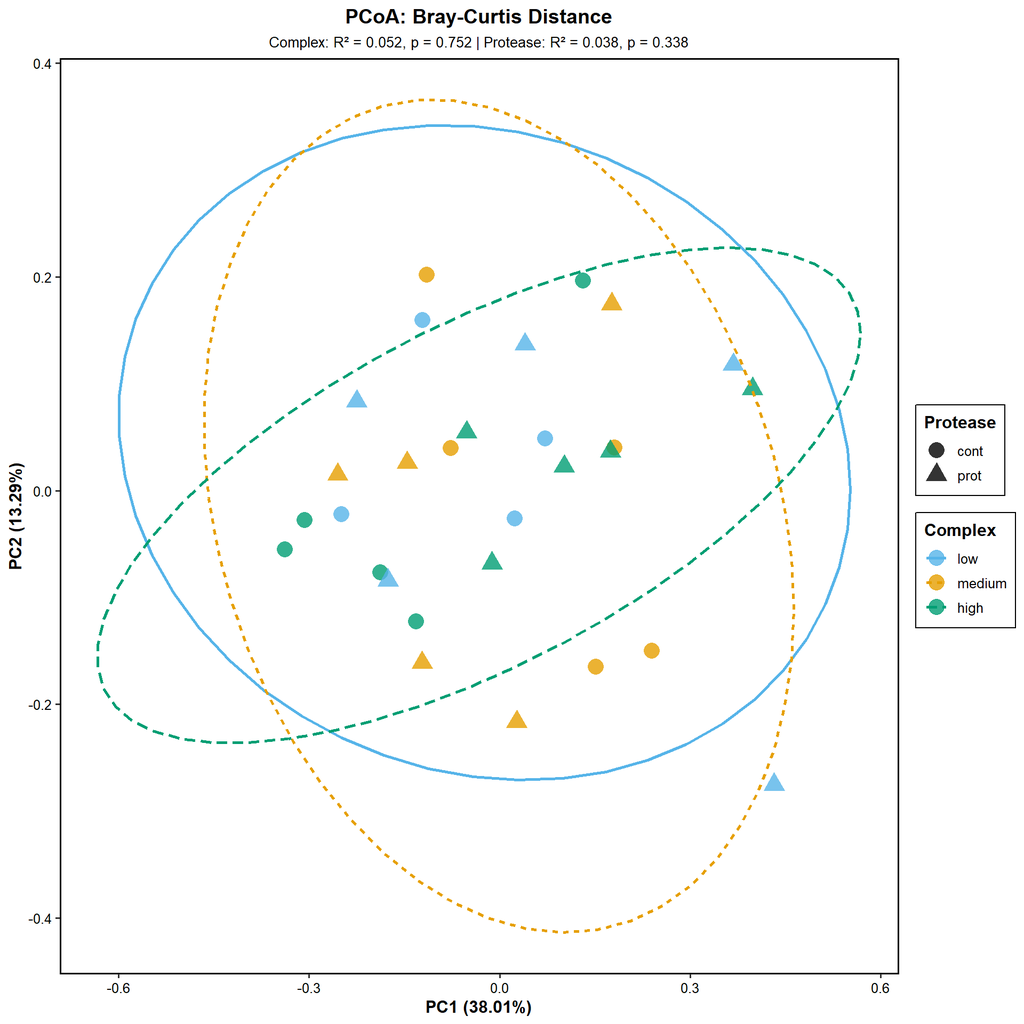

```r
# Combined plot with color = complex, shape = protease
p_combined <- ggplot(pcoa_bray_df, aes(x = PC1, y = PC2, color = complex, shape = protease)) +
  geom_point(size = 5, alpha = 0.8) +
  stat_ellipse(aes(group = complex, linetype = complex), level = 0.95, linewidth = 1) +
  scale_color_manual(values = complex_colors) +
  scale_shape_manual(values = c("cont" = 16, "prot" = 17)) +
  labs(
    x = paste0("PC1 (", var_explained_bray[1], "%)"),
    y = paste0("PC2 (", var_explained_bray[2], "%)"),
    color = "Complex",
    shape = "Protease",
    linetype = "Complex",
    title = "PCoA: Bray-Curtis Distance",
    subtitle = paste0("Complex: R² = ", r2_complex_bray, ", ",
                      ifelse(p_complex_bray < 0.001, "p < 0.001", paste0("p = ", round(p_complex_bray, 3))),
                      " | Protease: R² = ", r2_protease_bray, ", ",
                      ifelse(p_protease_bray < 0.001, "p < 0.001", paste0("p = ", round(p_protease_bray, 3))))
  ) +
  theme_publication +
  theme(
    plot.subtitle = element_text(hjust = 0.5, size = 10),
    legend.position = "right"
  )

p_combined
```

#### Summary table of PERMANOVA results:

```r
# Create summary table
permanova_summary <- data.frame(
  Distance = rep(c("Bray-Curtis", "Jaccard", "Aitchison"), each = 3),
  Factor = rep(c("Complex", "Protease", "Complex:Protease"), 3),
  R2 = c(
    permanova_bray_complex["Model", "R2"],
    permanova_bray_protease["Model", "R2"],
    permanova_bray_interaction["Model", "R2"],
    permanova_jaccard_complex["Model", "R2"],
    permanova_jaccard_protease["Model", "R2"],
    permanova_jaccard_interaction["Model", "R2"],
    permanova_aitchison_complex["Model", "R2"],
    permanova_aitchison_protease["Model", "R2"],
    permanova_aitchison_interaction["Model", "R2"]
  ),
  p_value = c(
    permanova_bray_complex["Model", "Pr(>F)"],
    permanova_bray_protease["Model", "Pr(>F)"],
    permanova_bray_interaction["Model", "Pr(>F)"],
    permanova_jaccard_complex["Model", "Pr(>F)"],
    permanova_jaccard_protease["Model", "Pr(>F)"],
    permanova_jaccard_interaction["Model", "Pr(>F)"],
    permanova_aitchison_complex["Model", "Pr(>F)"],
    permanova_aitchison_protease["Model", "Pr(>F)"],
    permanova_aitchison_interaction["Model", "Pr(>F)"]
  )
)

permanova_summary$significance <- ifelse(permanova_summary$p_value < 0.001, "***",
                                  ifelse(permanova_summary$p_value < 0.01, "**",
                                  ifelse(permanova_summary$p_value < 0.05, "*", "ns")))

kable(permanova_summary, digits = 4, caption = "PERMANOVA Summary: All Distance Metrics")
```

PERMANOVA Summary: All Distance Metrics

| Distance | Factor | R2 | p_value | significance |
| --- | --- | --- | --- | --- |
| Bray-Curtis | Complex | 0.0520 | 0.752 | ns |
| Bray-Curtis | Protease | 0.0377 | 0.338 | ns |
| Bray-Curtis | Complex:Protease | 0.1936 | 0.315 | ns |
| Jaccard | Complex | 0.0844 | 0.186 | ns |
| Jaccard | Protease | 0.0307 | 0.618 | ns |
| Jaccard | Complex:Protease | 0.2089 | 0.094 | ns |
| Aitchison | Complex | 0.0740 | 0.325 | ns |
| Aitchison | Protease | 0.0308 | 0.678 | ns |
| Aitchison | Complex:Protease | 0.1997 | 0.110 | ns |

## Differential Abundance Analysis

### Prepare data for differential abundance:

```r
# ALDEx2 and ANCOM-BC need taxa as rows and samples as columns
# species_counts is already in this format

# Filter low-prevalence taxa (present in at least 10% of samples)
prevalence <- rowSums(species_counts > 0) / ncol(species_counts)
species_counts_filtered <- species_counts[prevalence >= 0.10, ]


# Check dimensions
dim(species_counts_filtered)
```

```
[1] 1245   29
```

```r
# Verify sample order matches metadata
all(colnames(species_counts_filtered) == rownames(meta_tab))
```

```
[1] TRUE
```

### ALDEx2 Analysis

#### ALDEx2 for Complex factor:

```r
# ALDEx2 requires character or factor for conditions
# For 3-level factor, use aldex.kw (Kruskal-Wallis)
meta_tab$complex <- as.character(meta_tab$complex)
set.seed(123)
aldex_complex <- aldex.clr(species_counts_filtered,
                            meta_tab$complex,
                            mc.samples = 128,
                            denom = "all",
                            verbose = FALSE)

# Kruskal-Wallis test for 3 groups
aldex_complex_kw <- aldex.kw(aldex_complex)

# Add taxon names
aldex_complex_kw$taxon <- rownames(aldex_complex_kw)

# Filter significant results (using glm.eBH for FDR-corrected p-values)
aldex_complex_sig <- aldex_complex_kw[aldex_complex_kw$kw.eBH < 0.05, ]

# Sort by p-value
aldex_complex_sig <- aldex_complex_sig[order(aldex_complex_sig$kw.eBH), ]

# Display results
nrow(aldex_complex_sig)
```

```
[1] 0
```

```r
kable(head(aldex_complex_sig, 20), digits = 4,
      caption = "ALDEx2: Significant taxa by Complex (KW test, BH adjusted p < 0.05)")
```

ALDEx2: Significant taxa by Complex (KW test, BH adjusted p < 0.05)

| kw.ep | kw.eBH | glm.ep | glm.eBH | taxon |
| --- | --- | --- | --- | --- |

#### ALDEx2 for Protease factor:

```r
# For 2-level factor, use aldex.ttest (Welch's t-test and Wilcoxon)
meta_tab$protease <- as.character(meta_tab$protease)
set.seed(123)
aldex_protease <- aldex.clr(species_counts_filtered,
                             meta_tab$protease,
                             mc.samples = 128,
                             denom = "all",
                             verbose = FALSE)

# t-test and Wilcoxon test
aldex_protease_tt <- aldex.ttest(aldex_protease)

# Effect size
aldex_protease_effect <- aldex.effect(aldex_protease)

# Combine results
aldex_protease_all <- data.frame(aldex_protease_tt, aldex_protease_effect)
aldex_protease_all$taxon <- rownames(aldex_protease_all)

# Filter significant results (Wilcoxon BH-adjusted)
aldex_protease_sig <- aldex_protease_all[aldex_protease_all$wi.eBH < 0.05, ]

# Sort by effect size
aldex_protease_sig <- aldex_protease_sig[order(abs(aldex_protease_sig$effect), decreasing = TRUE), ]

nrow(aldex_protease_sig)
```

```
[1] 0
```

```r
kable(head(aldex_protease_sig[, c("taxon", "wi.eBH", "effect", "overlap")], 20), digits = 4,
      caption = "ALDEx2: Significant taxa by Protease (Wilcoxon, BH adjusted p < 0.05)")
```

ALDEx2: Significant taxa by Protease (Wilcoxon, BH adjusted p < 0.05)

| taxon | wi.eBH | effect | overlap |
| --- | --- | --- | --- |

#### **ALDEx2 Effect Size Plot - Protease:**

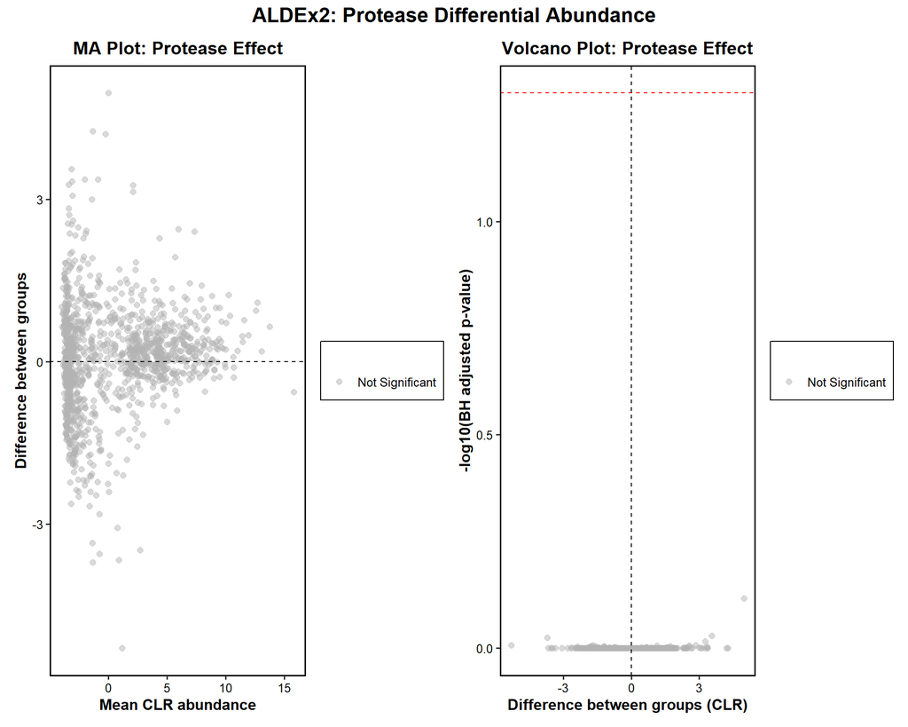

```r
# Prepare data for plotting
aldex_protease_all$significant <- ifelse(aldex_protease_all$wi.eBH < 0.05, "Significant", "Not Significant")
aldex_protease_all$direction <- ifelse(aldex_protease_all$effect > 0, "Higher in prot", "Higher in cont")

# MA plot (Bland-Altman)
p1 <- ggplot(aldex_protease_all, aes(x = rab.all, y = diff.btw, color = significant)) +
  geom_point(alpha = 0.5, size = 2) +
  scale_color_manual(values = c("Significant" = "#D55E00", "Not Significant" = "grey70")) +
  geom_hline(yintercept = 0, linetype = "dashed", color = "black") +
  labs(
    x = "Mean CLR abundance",
    y = "Difference between groups",
    color = "",
    title = "MA Plot: Protease Effect"
  ) +
  theme_publication

# Effect size plot
p2 <- ggplot(aldex_protease_all, aes(x = diff.btw, y = -log10(wi.eBH), color = significant)) +
  geom_point(alpha = 0.5, size = 2) +
  scale_color_manual(values = c("Significant" = "#D55E00", "Not Significant" = "grey70")) +
  geom_hline(yintercept = -log10(0.05), linetype = "dashed", color = "red") +
  geom_vline(xintercept = 0, linetype = "dashed", color = "black") +
  labs(
    x = "Difference between groups (CLR)",
    y = "-log10(BH adjusted p-value)",
    color = "",
    title = "Volcano Plot: Protease Effect"
  ) +
  theme_publication

p1 + p2 +
  plot_annotation(title = "ALDEx2: Protease Differential Abundance",
                  theme = theme(plot.title = element_text(hjust = 0.5, face = "bold", size = 16)))
```

#### **ALDEx2 for Interaction (using glm):**

Os resultados abaixo mostra a mesma coisa, não foi segnificativo para quando ajusta para FDR mas tem varios taxons que foi significativo. Isso é um conceito importante pq mudar o seu resultado completamente. Da uma lida nesse documento https://totallab.com/resources/p-values-fdr-q-values/

```r
# Create model matrix for interaction
meta_tab$complex <- factor(meta_tab$complex, levels = c("low", "medium", "high"))
meta_tab$protease <- factor(meta_tab$protease, levels = c("cont", "prot"))

mm <- model.matrix(~ complex * protease, data = meta_tab)

set.seed(123)
aldex_interaction <- aldex.clr(species_counts_filtered,
                                mm,
                                mc.samples = 128,
                                denom = "all",
                                verbose = FALSE)

# GLM test
aldex_interaction_glm <- aldex.glm(aldex_interaction, mm)
```

```
|------------(25%)----------(50%)----------(75%)----------|
```

```r
# Extract interaction term results
interaction_cols <- grep("complex.*protease", colnames(aldex_interaction_glm), value = TRUE)

# Get p-values for interaction terms
aldex_interaction_results <- aldex_interaction_glm[, c(interaction_cols)]
aldex_interaction_results$taxon <- rownames(aldex_interaction_results)

# Find significant interactions (any interaction term)
pval_cols <- grep("pval.eBH", interaction_cols, value = TRUE)

if (length(pval_cols) > 0) {
  aldex_interaction_results$min_pval <- apply(aldex_interaction_results[, pval_cols, drop = FALSE], 1, min, na.rm = TRUE)
  aldex_interaction_sig <- aldex_interaction_results[aldex_interaction_results$min_pval < 0.05, ]
  aldex_interaction_sig <- aldex_interaction_sig[order(aldex_interaction_sig$min_pval), ]

  nrow(aldex_interaction_sig)
  kable(head(aldex_interaction_sig, 20), digits = 4,
        caption = "ALDEx2: Significant taxa with Complex × Protease interaction (BH adjusted p < 0.05)")
}
```

### ANCOM-BC Analysis

Aqui eu usei outro metodo para achar diferença entre as especies. Tambem não achou nada significativo ajustando para FDR. Entretanto, o ultimo heat map eu coloquei para fazer coloca ros que deu siginificativo na interação. Tem bastante coisa legal, vc precisa namorar um pouco para ver qual é do seu interesse.

### Create phyloseq object for ANCOM-BC:

#### Remove zero-variance taxa before ANCOM-BC:

```r
# Create interaction group
meta_tab$interaction_group <- interaction(meta_tab$complex, meta_tab$protease, sep = "_")

# Check how many samples per interaction group
table(meta_tab$interaction_group)
```

```
   low_cont medium_cont   high_cont    low_prot medium_prot   high_prot
          4           5           5           5           5           5
```

```r
# Function to identify problematic taxa
find_zero_variance_taxa <- function(counts_mat, group_var) {
  problem_taxa <- c()

  for (taxon in rownames(counts_mat)) {
    counts <- as.numeric(counts_mat[taxon, ])

    for (grp in unique(group_var)) {
      grp_counts <- counts[group_var == grp]

      # Check if all values are the same (zero variance)
      if (length(unique(grp_counts)) == 1) {
        problem_taxa <- c(problem_taxa, taxon)
        break
      }
    }
  }

  return(unique(problem_taxa))
}

# Find problematic taxa for interaction groups
problem_taxa <- find_zero_variance_taxa(species_counts_filtered, meta_tab$interaction_group)

length(problem_taxa)
```

```
[1] 589
```

```r
# Remove problematic taxa
species_counts_interaction <- species_counts_filtered[!rownames(species_counts_filtered) %in% problem_taxa, ]

dim(species_counts_interaction)
```

```
[1] 656  29
```

```r
#| label: filter-min-counts-per-group

# For each taxon, require at least 2 non-zero values in each interaction group
keep_taxa <- apply(species_counts_interaction, 1, function(x) {
  counts <- as.numeric(x)

  all_groups_ok <- TRUE
  for (grp in unique(meta_tab$interaction_group)) {
    grp_counts <- counts[meta_tab$interaction_group == grp]

    # Require at least 2 non-zero values AND variance > 0
    n_nonzero <- sum(grp_counts > 0)
    has_variance <- var(grp_counts) > 0

    if (n_nonzero < 2 | !has_variance) {
      all_groups_ok <- FALSE
      break
    }
  }

  return(all_groups_ok)
})

species_counts_interaction <- species_counts_interaction[keep_taxa, ]

dim(species_counts_interaction)
```

```
[1] 508  29
```

```r
#| label: create-ps-interaction

# Create phyloseq object with filtered data
otu_interaction <- otu_table(species_counts_interaction, taxa_are_rows = TRUE)
sample_interaction <- sample_data(meta_tab)

ps <- phyloseq(otu_interaction, sample_interaction)

ps
```

```
phyloseq-class experiment-level object
otu_table()   OTU Table:         [ 508 taxa and 29 samples ]
sample_data() Sample Data:       [ 29 samples by 9 sample variables ]
```

#### ANCOM-BC for Complex factor

```r
set.seed(123)
ancom_complex <- ancombc2(
  data = ps,
  fix_formula = "complex",
  p_adj_method = "BH",
  prv_cut = 0.10,
  lib_cut = 1000,
  group = "complex",
  struc_zero = FALSE,
  neg_lb = FALSE,
  alpha = 0.05,
  global = TRUE,
  pairwise = TRUE,
  dunnet = FALSE,
  trend = FALSE,
  verbose = FALSE
)

# Extract results
ancom_complex_res <- ancom_complex$res

# Filter significant (q < 0.05 for any comparison)
ancom_complex_sig <- ancom_complex_res %>%
  filter(q_complexmedium < 0.05 | q_complexhigh < 0.05)

nrow(ancom_complex_sig)
```

```
[1] 0
```

```r
kable(head(ancom_complex_sig[, c("taxon", "lfc_complexmedium", "lfc_complexhigh",
                                  "q_complexmedium", "q_complexhigh")], 20),
      digits = 4,
      caption = "ANCOM-BC: Significant taxa by Complex (BH adjusted q < 0.05)")
```

ANCOM-BC: Significant taxa by Complex (BH adjusted q < 0.05)

| taxon | lfc_complexmedium | lfc_complexhigh | q_complexmedium | q_complexhigh |
| --- | --- | --- | --- | --- |

#### ANCOM-BC for Protease factor:

```r
set.seed(123)
ancom_protease <- ancombc2(
  data = ps,
  fix_formula = "protease",
  p_adj_method = "BH",
  prv_cut = 0.10,
  lib_cut = 1000,
  group = NULL,
  struc_zero = FALSE,
  neg_lb = FALSE,
  alpha = 0.05,
  global = FALSE,
  pairwise = FALSE,
  dunnet = FALSE,
  trend = FALSE,
  verbose = FALSE
)

# Extract results
ancom_protease_res <- ancom_protease$res

# Filter significant
ancom_protease_sig <- ancom_protease_res %>%
  filter(q_proteaseprot < 0.05)

# Sort by log fold change
ancom_protease_sig <- ancom_protease_sig[order(abs(ancom_protease_sig$lfc_proteaseprot), decreasing = TRUE), ]

nrow(ancom_protease_sig)
```

```
[1] 0
```

```r
kable(head(ancom_protease_sig[, c("taxon", "lfc_proteaseprot", "se_proteaseprot",
                                   "q_proteaseprot")], 20),
      digits = 4,
      caption = "ANCOM-BC: Significant taxa by Protease (BH adjusted q < 0.05)")
```

ANCOM-BC: Significant taxa by Protease (BH adjusted q < 0.05)

| taxon | lfc_proteaseprot | se_proteaseprot | q_proteaseprot |
| --- | --- | --- | --- |